# How user_type and member_gender affects rides start time and duration of Ford GoBike System Data

## by (Mustapha Olalekan Alaba)

## Investigation Overview

My presentation will be focusing on what time of the day and day of week more rides are taking putting into consideration the ride duration and how user_type and member gender affects ride time and duration.

## Dataset Overview

There are total of 183,412 bike rides record with 16 features. 197 of the rides records were dropped due to missing start and end station information. 8,265 of the records are missing the riders member_birth_year and member_gender information. The missing member gender was replaced with Not Applicable(NA). Extra features (duration_min, hour_of_the_day and start_day) were created to ease plotting. All rides with more than an hour duration were considered outliers for this presentation and were removed

## Rides count per day of the week

More rides are taken during the week days (Monday to Firday), Thursday having the most rides. Weekend rides are just about half of the rides that happens on week days.

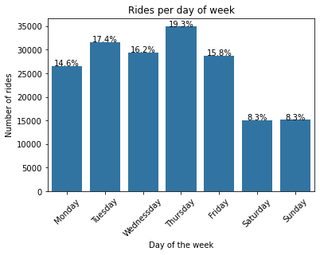

## Distribution of rides by time of the day

We notice that we have two peak time first one between 8am and 9am, also between 5pm and 6pm. There is also a slight increase in rides taken between midday and 1:30pm.

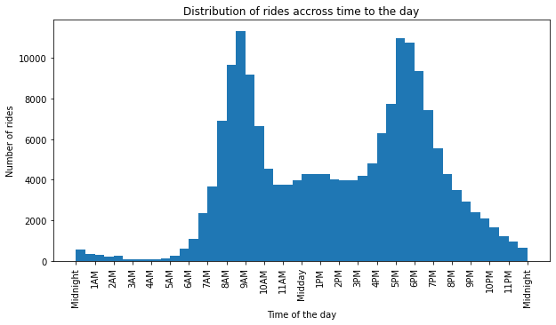

## Rides count by Gender

The male Gender took 71.4% of all rides in the dataset while the Female gender took 22.3%.

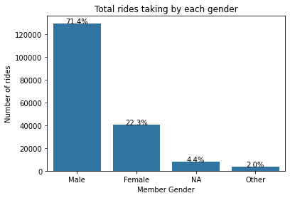

## Gender vs Day of week

For weekdays, the male percentage was around 71-72% but drops below 70% for saturdays and sundays. other gender have slight increase in percentage for weekends.

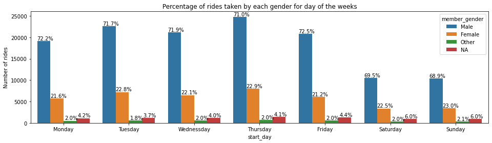

## Ride Duration vs Day of week

We will notice that, the week days Monday - Friday, roughly have same average ride duration of 10mins and same range while the weekends have higher average duration (almost 12mins) and range. For both the weekdays and weekends, there are outliers, starting at 25mins for weekdays and roughly 30mins for weekends.

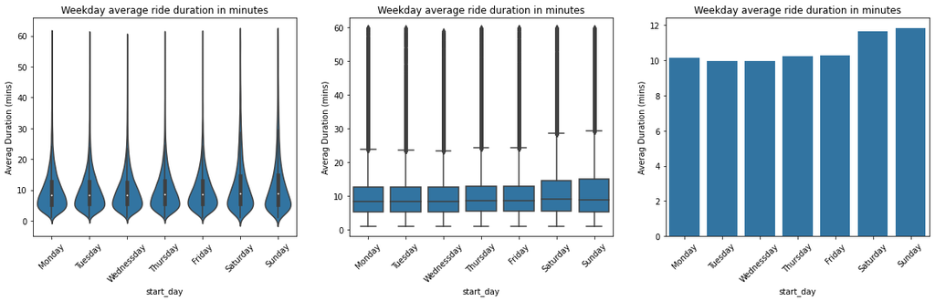

## User type vs ride duration for each day of the week

The subscriber user type have rides for 10mins on average while the Customer have higher average time and ride longer during the weekends. The majority of the trips are done by the subscribers.

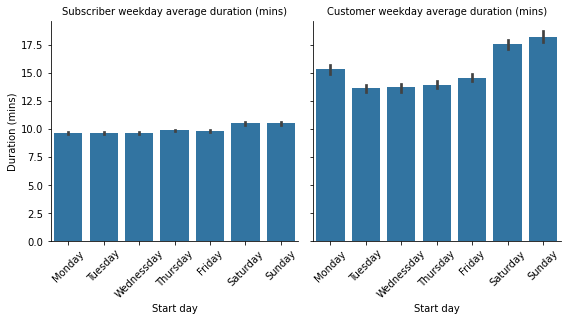

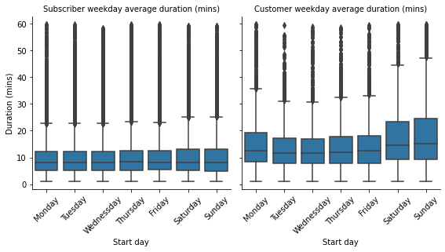